# Fundamentos_Estadistica_Inferencial_Python

## Fundamentos de Estadistica Inferencial con Python

**Realizado en el curso modalidad virtual estudiante Richard Douglas Grijalba**

### **curso de Grow Up analytics**

[figure not shown]

### Pruebas de Hipótesis con variables Cualitativas

```python
# importar librerias de trabajo
import pandas as pd
import seaborn as sns
import numpy as np
import dc_stat_think as dcst
import matplotlib.pyplot as plt
```

en caso de no tener instalado o activo el paquete de dc_stat_think, se procede a instalar --> pip install dc_stat_think

https://pypi.org/project/dc-stat-think/

### Verifiar Datos de Trabajo

```python
import os
```

```python
os.getcwd()
```

```
'C:\\Users\\Rdouglas\\Estadistica Inferencial con Python'
```

```python
#cargar los datos el archivo

datos = pd.read_csv("C:\\Users\\Rdouglas\\Documents\\Python Scripts\\curso Grow Up\\Estadistica Inferencial Python\\NHANES.csv")
datos.head()
```

|  | ID | SurveyYr | Gender | Age | AgeDecade | AgeMonths | Race1 | Race3 | Education | MaritalStatus | ... | RegularMarij | AgeRegMarij | HardDrugs | SexEver | SexAge | SexNumPartnLife | SexNumPartYear | SameSex | SexOrientation | PregnantNow |
| --- | --- | --- | --- | --- | --- | --- | --- | --- | --- | --- | --- | --- | --- | --- | --- | --- | --- | --- | --- | --- | --- |
| 0 | 51624 | 2009_10 | male | 34 | 30-39 | 409.0 | White | NaN | High School | Married | ... | No | NaN | Yes | Yes | 16.0 | 8.0 | 1.0 | No | Heterosexual | NaN |
| 1 | 51624 | 2009_10 | male | 34 | 30-39 | 409.0 | White | NaN | High School | Married | ... | No | NaN | Yes | Yes | 16.0 | 8.0 | 1.0 | No | Heterosexual | NaN |
| 2 | 51624 | 2009_10 | male | 34 | 30-39 | 409.0 | White | NaN | High School | Married | ... | No | NaN | Yes | Yes | 16.0 | 8.0 | 1.0 | No | Heterosexual | NaN |
| 3 | 51625 | 2009_10 | male | 4 | 0-9 | 49.0 | Other | NaN | NaN | NaN | ... | NaN | NaN | NaN | NaN | NaN | NaN | NaN | NaN | NaN | NaN |
| 4 | 51630 | 2009_10 | female | 49 | 40-49 | 596.0 | White | NaN | Some College | LivePartner | ... | No | NaN | Yes | Yes | 12.0 | 10.0 | 1.0 | Yes | Heterosexual | NaN |

5 rows × 76 columns

**Generar una exploración rapida del Dataset**

```python
datos.info()
```

```
<class 'pandas.core.frame.DataFrame'>
RangeIndex: 10000 entries, 0 to 9999
Data columns (total 76 columns):
 #   Column            Non-Null Count  Dtype
---  ------            --------------  -----
 0   ID                10000 non-null  int64
 1   SurveyYr          10000 non-null  object
 2   Gender            10000 non-null  object
 3   Age               10000 non-null  int64
 4   AgeDecade         9667 non-null   object
 5   AgeMonths         4962 non-null   float64
 6   Race1             10000 non-null  object
 7   Race3             5000 non-null   object
 8   Education         7221 non-null   object
 9   MaritalStatus     7231 non-null   object
```

[output cut: 68 more lines]

```python
datos.shape
```

```
(10000, 76)
```

```python
datos.describe().T
```

|  | count | mean | std | min | 25% | 50% | 75% | max |
| --- | --- | --- | --- | --- | --- | --- | --- | --- |
| ID | 10000.0 | 61944.643800 | 5871.167160 | 51624.00 | 56904.500 | 62159.500 | 67039.000 | 71915.000 |
| Age | 10000.0 | 36.742100 | 22.397566 | 0.00 | 17.000 | 36.000 | 54.000 | 80.000 |
| AgeMonths | 4962.0 | 420.123942 | 259.043091 | 0.00 | 199.000 | 418.000 | 624.000 | 959.000 |
| HHIncomeMid | 9189.0 | 57206.170421 | 33020.276584 | 2500.00 | 30000.000 | 50000.000 | 87500.000 | 100000.000 |
| Poverty | 9274.0 | 2.801844 | 1.677909 | 0.00 | 1.240 | 2.700 | 4.710 | 5.000 |
| HomeRooms | 9931.0 | 6.248918 | 2.277538 | 1.00 | 5.000 | 6.000 | 8.000 | 13.000 |
| Weight | 9922.0 | 70.981798 | 29.125357 | 2.80 | 56.100 | 72.700 | 88.900 | 230.700 |
| Length | 543.0 | 85.016022 | 13.705026 | 47.10 | 75.700 | 87.000 | 96.100 | 112.200 |
| HeadCirc | 88.0 | 41.180682 | 2.311483 | 34.20 | 39.575 | 41.450 | 42.925 | 45.400 |
| Height | 9647.0 | 161.877838 | 20.186567 | 83.60 | 156.800 | 166.000 | 174.500 | 200.400 |
| BMI | 9634.0 | 26.660136 | 7.376579 | 12.88 | 21.580 | 25.980 | 30.890 | 81.250 |
| Pulse | 8563.0 | 73.559734 | 12.155422 | 40.00 | 64.000 | 72.000 | 82.000 | 136.000 |
| BPSysAve | 8551.0 | 118.154953 | 17.248170 | 76.00 | 106.000 | 116.000 | 127.000 | 226.000 |
| BPDiaAve | 8551.0 | 67.480061 | 14.354804 | 0.00 | 61.000 | 69.000 | 76.000 | 116.000 |
| BPSys1 | 8237.0 | 119.090203 | 17.496360 | 72.00 | 106.000 | 116.000 | 128.000 | 232.000 |
| BPDia1 | 8237.0 | 68.278257 | 13.780781 | 0.00 | 62.000 | 70.000 | 76.000 | 118.000 |
| BPSys2 | 8353.0 | 118.475757 | 17.491327 | 76.00 | 106.000 | 116.000 | 128.000 | 226.000 |
| BPDia2 | 8353.0 | 67.664552 | 14.419781 | 0.00 | 60.000 | 68.000 | 76.000 | 118.000 |
| BPSys3 | 8365.0 | 117.929229 | 17.177186 | 76.00 | 106.000 | 116.000 | 126.000 | 226.000 |
| BPDia3 | 8365.0 | 67.298745 | 14.958393 | 0.00 | 60.000 | 68.000 | 76.000 | 116.000 |
| Testosterone | 4126.0 | 197.898000 | 226.504485 | 0.25 | 17.700 | 43.820 | 362.410 | 1795.600 |
| DirectChol | 8474.0 | 1.364865 | 0.399258 | 0.39 | 1.090 | 1.290 | 1.580 | 4.030 |
| TotChol | 8474.0 | 4.879220 | 1.075583 | 1.53 | 4.110 | 4.780 | 5.530 | 13.650 |
| UrineVol1 | 9013.0 | 118.516143 | 90.336481 | 0.00 | 50.000 | 94.000 | 164.000 | 510.000 |
| UrineFlow1 | 8397.0 | 0.979295 | 0.949514 | 0.00 | 0.403 | 0.699 | 1.221 | 17.167 |
| UrineVol2 | 1478.0 | 119.675913 | 90.160054 | 0.00 | 52.000 | 95.000 | 171.750 | 409.000 |
| UrineFlow2 | 1476.0 | 1.149372 | 1.072948 | 0.00 | 0.475 | 0.760 | 1.513 | 13.692 |
| DiabetesAge | 629.0 | 48.422893 | 15.680504 | 1.00 | 40.000 | 50.000 | 58.000 | 80.000 |
| DaysPhysHlthBad | 7532.0 | 3.334838 | 7.400700 | 0.00 | 0.000 | 0.000 | 3.000 | 30.000 |
| DaysMentHlthBad | 7534.0 | 4.126493 | 7.832971 | 0.00 | 0.000 | 0.000 | 4.000 | 30.000 |
| nPregnancies | 2604.0 | 3.026882 | 1.795341 | 1.00 | 2.000 | 3.000 | 4.000 | 32.000 |
| nBabies | 2416.0 | 2.456954 | 1.315227 | 0.00 | 2.000 | 2.000 | 3.000 | 12.000 |
| Age1stBaby | 1884.0 | 22.649682 | 4.772509 | 14.00 | 19.000 | 22.000 | 26.000 | 39.000 |
| SleepHrsNight | 7755.0 | 6.927531 | 1.346729 | 2.00 | 6.000 | 7.000 | 8.000 | 12.000 |
| PhysActiveDays | 4663.0 | 3.743513 | 1.836358 | 1.00 | 2.000 | 3.000 | 5.000 | 7.000 |
| TVHrsDayChild | 653.0 | 1.938744 | 1.434431 | 0.00 | 1.000 | 2.000 | 3.000 | 6.000 |
| CompHrsDayChild | 653.0 | 2.197550 | 2.516667 | 0.00 | 0.000 | 1.000 | 6.000 | 6.000 |
| AlcoholDay | 4914.0 | 2.914123 | 3.182672 | 1.00 | 1.000 | 2.000 | 3.000 | 82.000 |
| AlcoholYear | 5922.0 | 75.101655 | 103.033738 | 0.00 | 3.000 | 24.000 | 104.000 | 364.000 |
| SmokeAge | 3080.0 | 17.826623 | 5.326660 | 6.00 | 15.000 | 17.000 | 19.000 | 72.000 |
| AgeFirstMarij | 2891.0 | 17.022829 | 3.895010 | 1.00 | 15.000 | 16.000 | 19.000 | 48.000 |
| AgeRegMarij | 1366.0 | 17.691069 | 4.806103 | 5.00 | 15.000 | 17.000 | 19.000 | 52.000 |
| SexAge | 5540.0 | 17.428700 | 3.716551 | 9.00 | 15.000 | 17.000 | 19.000 | 50.000 |
| SexNumPartnLife | 5725.0 | 15.085066 | 57.846434 | 0.00 | 2.000 | 5.000 | 12.000 | 2000.000 |
| SexNumPartYear | 4928.0 | 1.342330 | 2.782688 | 0.00 | 1.000 | 1.000 | 1.000 | 69.000 |

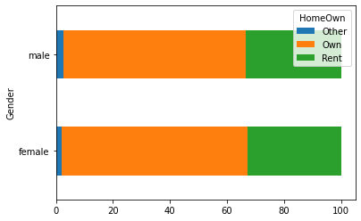

```python
#crear un grafico barras de 100%
grafico= pd.crosstab(datos.Gender,datos.HomeOwn)
grafico_porcentuales= grafico.apply(lambda x: (x*100)/sum(x),axis=1)
grafico_porcentuales.plot.barh(stacked=True);

# el grafico de barra horizontal se utiliza para variables cualitativas

# los verticales para variables cuantitativas o tiempo
```

### 1.4 Planteamiento de Hipotesis

**¿Qué es una prueba de hipótesis?** Una prueba de hipótesis es una regla que especifica si se puede aceptar o rechazar una afirmación acerca de una población dependiendo de la evidencia proporcionada por una muestra de datos.

**Una prueba de hipótesis examina dos hipótesis opuestas sobre una población: la hipótesis nula y la hipótesis alternativa.**

https://support.minitab.com/es-mx/minitab/18/help-and-how-to/statistics/basic-statistics/supporting-topics/basics/what-is-a-hypothesis-test/#:~:text=Una%20prueba%20de%20hip%C3%B3tesis%20es,nula%20y%20la%20hip%C3%B3tesis%20alternativa.

La hipótesis nula (H0) se refiere a la afirmación contraria a la que ha llegado el investigador. Es la hipótesis que el investigador pretender rechazar. Si tiene la evidencia suficiente para ello, podrá probar que lo contrario es cierto. Por lo tanto, la hipótesis alternativa (H1) es la conclusión a la que el investigador ha llegado a través de su investigación. https://economipedia.com/definiciones/hipotesis-nula.html

**Hipótesis nula (H0)** La hipótesis nula indica que un parámetro de población (tal como la media, la desviación estándar, etc.) es igual a un valor hipotético. La hipótesis nula suele ser una afirmación inicial que se basa en análisis previos o en conocimiento especializado.

**Hipótesis alternativa (H1)** La hipótesis alternativa indica que un parámetro de población es más pequeño, más grande o diferente del valor hipotético de la hipótesis nula. La hipótesis alternativa es lo que usted podría pensar que es cierto o espera probar que es cierto.

https://support.minitab.com/es-mx/minitab/18/help-and-how-to/statistics/basic-statistics/supporting-topics/basics/null-and-alternative-hypotheses/

otro aspecto relevante :

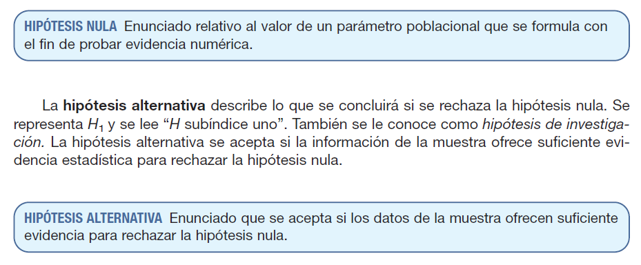

pag 336 Douglas A. Lind William G. Marchal Estadística aplicada a los negocios y la economía

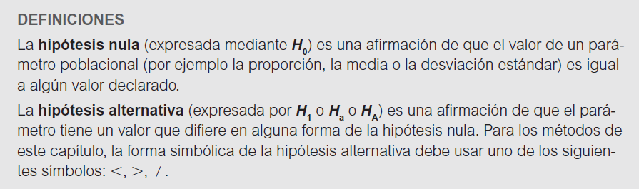

pag 359 Mario Triola Estadística

### 1.5 Prueba de hipotesis

Se realiza una seleccion de la variables a utilizar

```python
###  se realiza una seleccion de las variables necesarias

analisis = datos.loc[datos['HomeOwn'].isin(['Own','Rent']),['Gender','HomeOwn']]
analisis.head()
```

|  | Gender | HomeOwn |
| --- | --- | --- |
| 0 | male | Own |
| 1 | male | Own |
| 2 | male | Own |
| 3 | male | Own |
| 4 | female | Rent |

```python
#definir una funcion para permutaciones

def permutation_sample(data1,data2):
    """Genera una muestra permutada a partir de dos conjuntos de datos"""

    #concatenar los conjuntos de datos: data
    data = np.concatenate((data1,data2))


    #permutar el arreflo concatenado: datos permutados
    permuted_data = np.random.permutation(data)

    #dividir el arreglo permutado en dos
    perm_sample_1 = permuted_data[:len(data1)]
    perm_sample_2 = permuted_data[len(data1):]

    return perm_sample_1,perm_sample_2
```

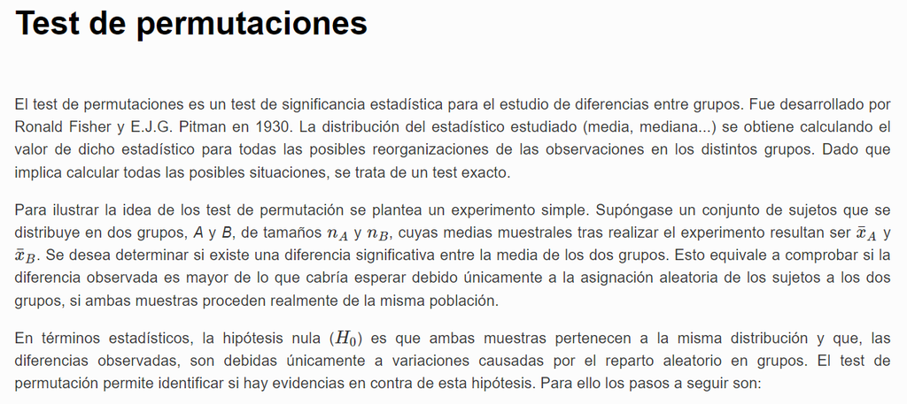

https://www.cienciadedatos.net/documentos/pystats03-test-permutacion-python.html

### 1.6 Generar Muestras Permutadas

```python
# Generate Permutation samples

perm_sample_1,perm_sample_2 = permutation_sample(
                                datos.loc[datos['Gender']=='male',['HomeOwn']],
                                datos.loc[datos['Gender']=='female',['HomeOwn']])
```

```python
print(perm_sample_1)
```

```
[['Rent']
 ['Rent']
 ['Own']
 ...
 ['Own']
 ['Own']
 ['Own']]
```

```python
print(perm_sample_2)
```

```
[['Rent']
 ['Own']
 ['Own']
 ...
 ['Rent']
 ['Own']
 ['Rent']]
```

```python
### Se crea la funcion para la diferencia de proporciones

def diff_of_props(data_1,data_2,value):
    """Diferencia entre los promedios de dos arreglos"""


    # Se calcula la diferencia entre las proporciones de datos 1 y datos 2: diff

    diff = np.mean(data_1[:,0]==value) - np.mean(data_2[:,0]==value)

    return diff
```

```python
# Generar la diferencia empírica (son los resultados segun la muestra que se obtiene)

diff_empiricas_prop = diff_of_props(perm_sample_1,perm_sample_2,'Own')
```

```python
diff_empiricas_prop  # se está comparando dos poblaciones, male y female, que tienen casa
                     # una permutacion genera un amuestra aleatoria de los datos
```

```
-0.0006600105601690665
```

### 1.8 Preparar Funcion Replicas de Permutaciones

```python
### Se generan las replicas de las permutaciones

#esta funcion recibe otra funcion (una funcion dentro de ota funcion)
def draw_perm_reps(data_1,data_2,func,value,size=1,prop=0):
    """Multiles repeticiones permutadas"""

    #Inicializar un arreglo (un tipo de matriz) de repeticines : perm_replicates
    perm_replicates = np.empty(size)

    for i in range(size):
        # Se genera la muestra permutada
        perm_sample_1,perm_sample_2 = permutation_sample(data_1,data_2)

        #computar el estadistico de prueba
        if prop == 0:
            perm_replicates[i]= func(perm_sample_1,perm_sample_2)
        elif prop ==1:
            perm_replicates[i]= func(perm_sample_1,perm_sample_2,value)

    return perm_replicates
```

### 1.9 ejecutar las Replicas de Permutaciones

por lo general la cantidad de repeticiones es de 10 mil, para acercarse a una distribucion normal

```python
# se generan 10 000 permutaciones o replicas : perm_replicates
perm_replicates = draw_perm_reps(datos.loc[datos['Gender'] == 'male',['HomeOwn']],
                                datos.loc[datos['Gender'] == 'female',['HomeOwn']],
                                diff_of_props, value= 'Own', size = 10000, prop =1)
```

```python
# la hpotesi nula indica que la proporcion de hombres y mujeres es la misma (dueños de hogar)
```

### 1.10 Calcular el Valor P

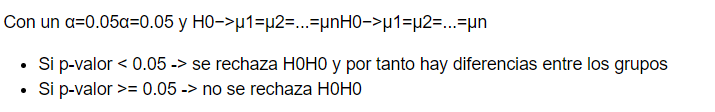

```python
# Se procede a calcular el valor P

p = np.sum(abs(perm_replicates) >= abs(diff_empiricas_prop)) / len(perm_replicates)
```

```python
print('p-value =', p)  # se imprime el resultado
                     # como el valor de P  dio mayor a 0.05 existe evidencia estadistica para no
                     # rechazar la hipotesis nula
```

```
p-value = 0.9479
```

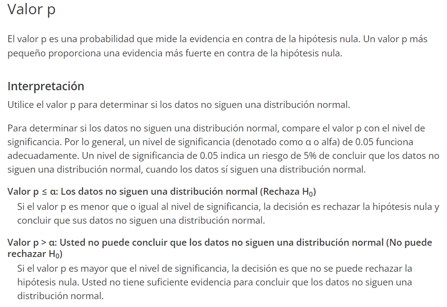

https://support.minitab.com/es-mx/minitab/19/help-and-how-to/statistics/basic-statistics/how-to/normality-test/interpret-the-results/all-statistics-and-graphs/#p-value

### 1.11 Graficar la region Critica

```python
# se inicia creando unos objetos

# Probar diferentes niveles de confianza

nvl_95 = np.percentile(perm_replicates,95)
nvl_975 = np.percentile(perm_replicates,97.5)
nvl_995 = np.percentile(perm_replicates,99.5)


nvl_5 = np.percentile(perm_replicates,5)
nvl_275 = np.percentile(perm_replicates,2.5)
nvl_005 = np.percentile(perm_replicates,0.5)
```

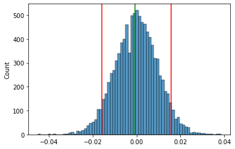

```python
# Graficar para un 90% de comfianza
sns.histplot(data=perm_replicates)
plt.axvline(diff_empiricas_prop, c="green")
plt.axvline(nvl_95, c="red")  # esto corresponde a las colas
plt.axvline(nvl_5, c="red");   # esto corresponde a las colas
```

### Interpretación de la Región Crítica según nivel de Confianza

### Realizo un captura del gráfico previamente generado

**porque posiblemente al volver a cargar los datos el gráfico o cálculo de permutaciones podría variar**

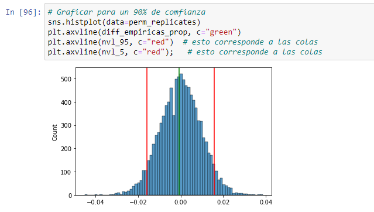

así fue como quedó el gráfico realizado durante la práctica

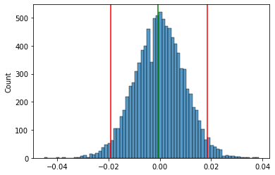

```python
# Graficar para un 95% de comfianza
sns.histplot(data=perm_replicates)
plt.axvline(diff_empiricas_prop, c="green")
plt.axvline(nvl_975, c="red")  # esto corresponde a las colas
plt.axvline(nvl_275, c="red");   # esto corresponde a las colas
```

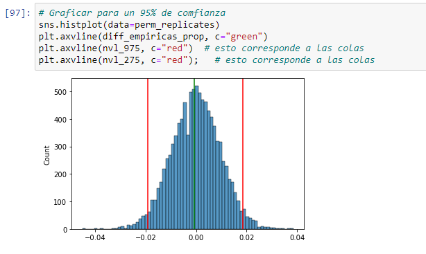

ambos graficos se ven similares, por la teoria del límite central. las lineas rojas se van achatando (moviendose más hacia las colas)

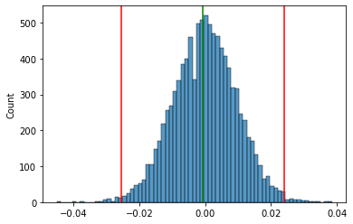

```python
# Graficar para un 99.5% de comfianza
sns.histplot(data=perm_replicates)
plt.axvline(diff_empiricas_prop, c="green")
plt.axvline(nvl_995, c="red")  # esto corresponde a las colas
plt.axvline(nvl_005, c="red");   # esto corresponde a las colas
```

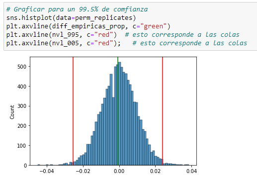

### Prueba de Hipotesis con Variables Cuantitativas

### 2.1 Exploracion Inicial de la variable de interes

```python
datos.head()
```

|  | ID | SurveyYr | Gender | Age | AgeDecade | AgeMonths | Race1 | Race3 | Education | MaritalStatus | ... | RegularMarij | AgeRegMarij | HardDrugs | SexEver | SexAge | SexNumPartnLife | SexNumPartYear | SameSex | SexOrientation | PregnantNow |
| --- | --- | --- | --- | --- | --- | --- | --- | --- | --- | --- | --- | --- | --- | --- | --- | --- | --- | --- | --- | --- | --- |
| 0 | 51624 | 2009_10 | male | 34 | 30-39 | 409.0 | White | NaN | High School | Married | ... | No | NaN | Yes | Yes | 16.0 | 8.0 | 1.0 | No | Heterosexual | NaN |
| 1 | 51624 | 2009_10 | male | 34 | 30-39 | 409.0 | White | NaN | High School | Married | ... | No | NaN | Yes | Yes | 16.0 | 8.0 | 1.0 | No | Heterosexual | NaN |
| 2 | 51624 | 2009_10 | male | 34 | 30-39 | 409.0 | White | NaN | High School | Married | ... | No | NaN | Yes | Yes | 16.0 | 8.0 | 1.0 | No | Heterosexual | NaN |
| 3 | 51625 | 2009_10 | male | 4 | 0-9 | 49.0 | Other | NaN | NaN | NaN | ... | NaN | NaN | NaN | NaN | NaN | NaN | NaN | NaN | NaN | NaN |
| 4 | 51630 | 2009_10 | female | 49 | 40-49 | 596.0 | White | NaN | Some College | LivePartner | ... | No | NaN | Yes | Yes | 12.0 | 10.0 | 1.0 | Yes | Heterosexual | NaN |

5 rows × 76 columns

```python
# supongamos que el estudio quiere analisar si el indice de masa corporal difiere entre hombres y mujeres
# en cual de los dos existe algo que indique que uno u otro se cuida más su peso
```

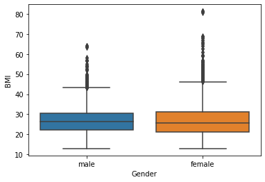

```python
#Primero realizar un grafico de boxplot

sns.boxplot(x="Gender",y="BMI", data=datos);
```

```python
# ahora lo que procede es, que por medio de cálculos estadisticos, probar si existe o no
# variaciones en el tema de masa o grasa corporal, entre hombres y mujeres
```

### 2.2 Calcular la Diferencia Empirica de Medias

```python
# probar si existe o no variaciones en el tema de masa o grasa corporal, entre hombres y mujeres
# se procede a seleccionar las variables de trabajo
analisis_cuantitativo = datos.loc[:,['Gender','BMI']]
analisis_cuantitativo = analisis_cuantitativo.dropna()  #esto permite quitar los Na (datos faltantes)
analisis_cuantitativo.head()
```

|  | Gender | BMI |
| --- | --- | --- |
| 0 | male | 32.22 |
| 1 | male | 32.22 |
| 2 | male | 32.22 |
| 3 | male | 15.30 |
| 4 | female | 30.57 |

```python
perm_sample_1,perm_sample_2 = permutation_sample(
                                analisis_cuantitativo.loc[analisis_cuantitativo['Gender'] == 'male',['BMI']],
                                analisis_cuantitativo.loc[analisis_cuantitativo['Gender'] == 'female',['BMI']]
                                )
```

```python
# definir la funcion

def diff_of_means(data_1,data_2):

    diff=np.mean(data_1) - np.mean(data_2)

    return diff
```

```python
diff_empiricas_medias = diff_of_means(perm_sample_1,perm_sample_2)
diff_empiricas_medias
```

```
0.04882340980203281
```

### 2.3 Planteamiento de Hipotesis Nula de Medias

```python
# se debe realizar replicas de permutaciones
perm_replicates = draw_perm_reps(analisis_cuantitativo.loc[analisis_cuantitativo['Gender'] == 'male',['BMI']],
                                analisis_cuantitativo.loc[analisis_cuantitativo['Gender'] == 'female',['BMI']],
                                 diff_of_means,value ="", size =10000, prop=0
                                )
```

```python
# determinar si estadisticamente existen diferencias entre ambos grupos
```

### 2.4 Calcular el valor P Hipotesis Cuantitativas

```python
p = np.sum(abs(perm_replicates) >=abs(diff_empiricas_medias)) / len(perm_replicates)

print('p-value',p)  # el valor para comparar por defecto es de 0.05
```

```
p-value 0.7435
```

por lo tanto si el valor de P es mayor a 0.05 no se rechaza

si P es menor entonces se rechaza y se acepta la Hipotesis alternativa

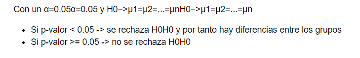

### 2.5 Graficar e Interpretar la Región Crítica Hipótesis Cuantitativas

```python
# Probar diferentes niveles de confianza

nvl_95 = np.percentile(perm_replicates,95)
nvl_975 = np.percentile(perm_replicates,97.5)
nvl_995 = np.percentile(perm_replicates,99.5)


nvl_5 = np.percentile(perm_replicates,5)
nvl_275 = np.percentile(perm_replicates,2.5)
nvl_005 = np.percentile(perm_replicates,0.5)
```

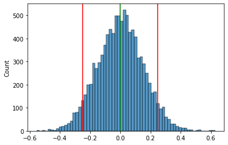

```python
# Graficar para un 90% de comfianza
sns.histplot(data=perm_replicates)
plt.axvline(diff_empiricas_prop, c="green")
plt.axvline(nvl_95, c="red")  # esto corresponde a las colas
plt.axvline(nvl_5, c="red");   # esto corresponde a las colas
```

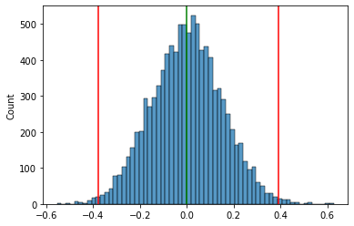

```python
# Graficar para un 99.5% de comfianza
sns.histplot(data=perm_replicates)
plt.axvline(diff_empiricas_prop, c="green")
plt.axvline(nvl_995, c="red")  # esto corresponde a las colas
plt.axvline(nvl_005, c="red");   # esto corresponde a las colas
```

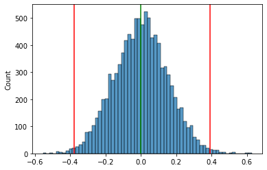

```python
# Graficar para un 99.5% de comfianza
sns.histplot(data=perm_replicates)
plt.axvline(diff_empiricas_prop, c="green")
plt.axvline(nvl_995, c="red")  # esto corresponde a las colas
plt.axvline(nvl_005, c="red");   # esto corresponde a las colas
```

**captura de los graficos que se desarrollaron**

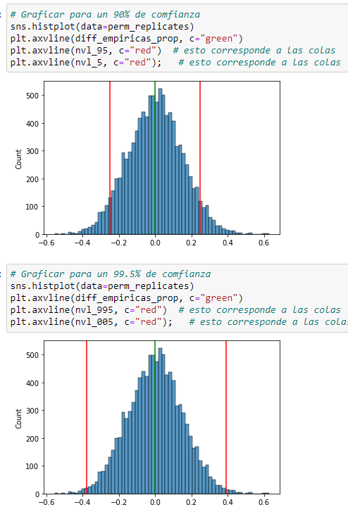

ambos graficos se ven similares, por la teoria del límite central. las lineas rojas se van achatando (moviendose más hacia las colas)